# HW 1

Barbara

November, 2015

### About

This was my first project for the **Reproducible Research** course in Coursera’s Data Science specialization track.

# Reproducible Research: Assessment 1

### Loading and preprocessing the data

##### Load the data (i.e. read.csv())

```r
if(!file.exists('activity.csv')){
    unzip('activity.zip')
}
activityData <- read.csv('activity.csv')
```

##### Process/transform the data (if necessary) into a format suitable for your analysis

```r
#activityData$interval <- strptime(gsub("([0-9]{1,2})([0-9]{2})", "\\1:\\2", activityData$interval), format='%H:%M')
```

### What is mean total number of steps taken per day?

```r
stepsPerDay <- tapply(activityData$steps, activityData$date, sum, na.rm=TRUE)
```

##### Make a histogram of the total number of steps taken each day

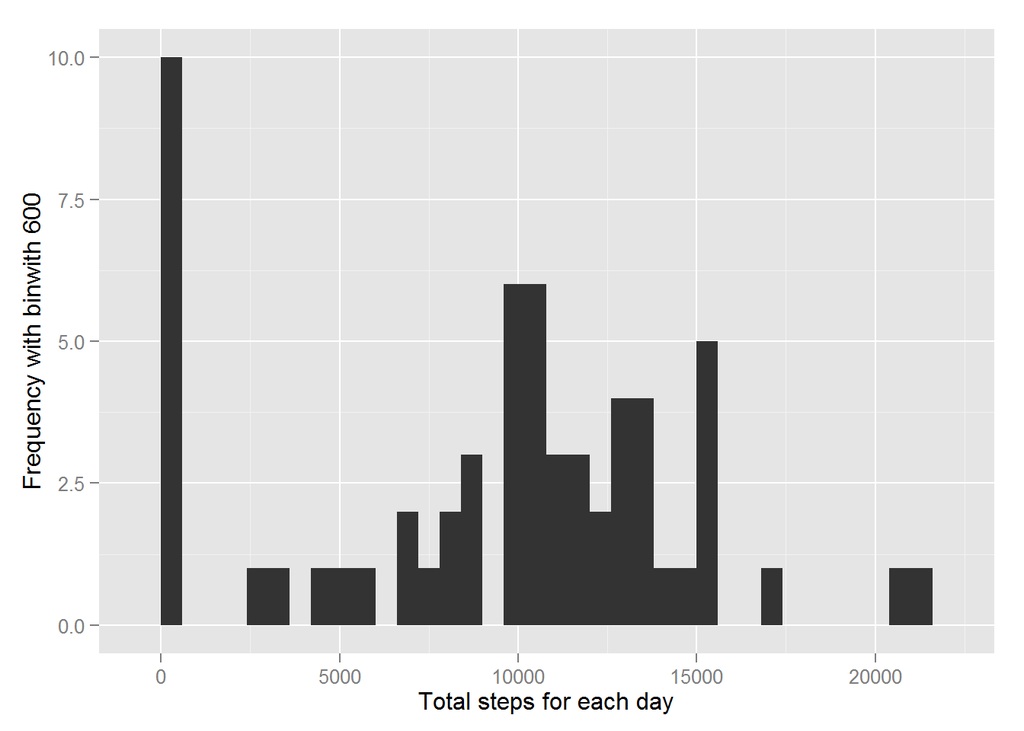

```r
qplot(stepsPerDay, xlab='Total steps for each day', ylab='Frequency with binwith 600', binwidth=600)
```

##### Calculate and report the mean and median total number of steps taken per day

```r
stepsPerDayMean <- mean(stepsPerDay)
stepsPerDayMedian <- median(stepsPerDay)
```

- The mean is: 9354.2295082
- The median is: 10395

### What is the average daily activity pattern?

```r
averagePerTimeblock <- aggregate(x=list(meanSteps=activityData$steps), by=list(interval=activityData$interval), FUN=mean, na.rm=TRUE)
```

##### Make a time series plot

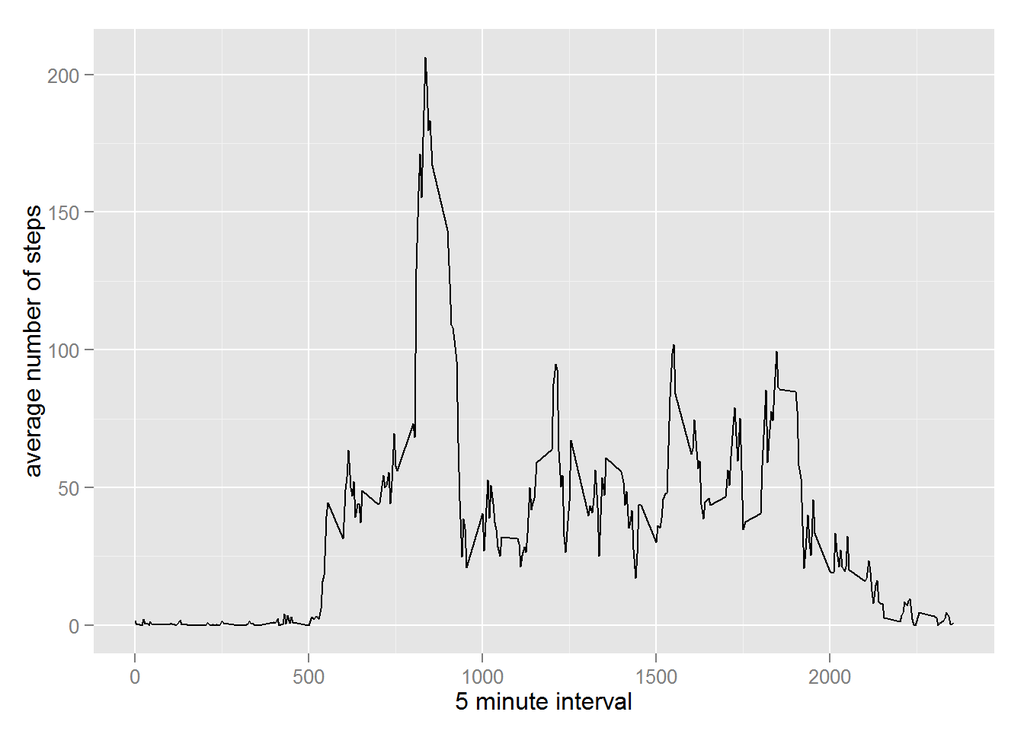

```r
ggplot(data=averagePerTimeblock, aes(x=interval, y=meanSteps)) +
    geom_line() +
    xlab("5 minute interval") +
    ylab("average number of steps")
```

##### Which 5-minute interval, on average across all the days in the dataset, contains the maximum number of steps?

```r
moststep <- which.max(averagePerTimeblock$meanSteps)
timeMostSteps <-  gsub("([0-9]{1,2})([0-9]{2})", "\\1:\\2", averagePerTimeblock[moststep,'interval'])
```

- Most Steps are onn the interval: 8:35

### Imputing missing values

##### Calculate and report the total number of missing values in the dataset

```r
numMissing <- length(which(is.na(activityData$steps)))
```

- The number of missing values is: 2304

##### Devise a strategy for filling in all of the missing values in the dataset.

##### Create a new dataset that is equal to the original dataset but with the missing data filled in.

```r
activityImputed <- activityData
activityImputed$steps <- impute(activityData$steps, fun=mean)
```

##### Make a histogram of the total number of steps taken each day

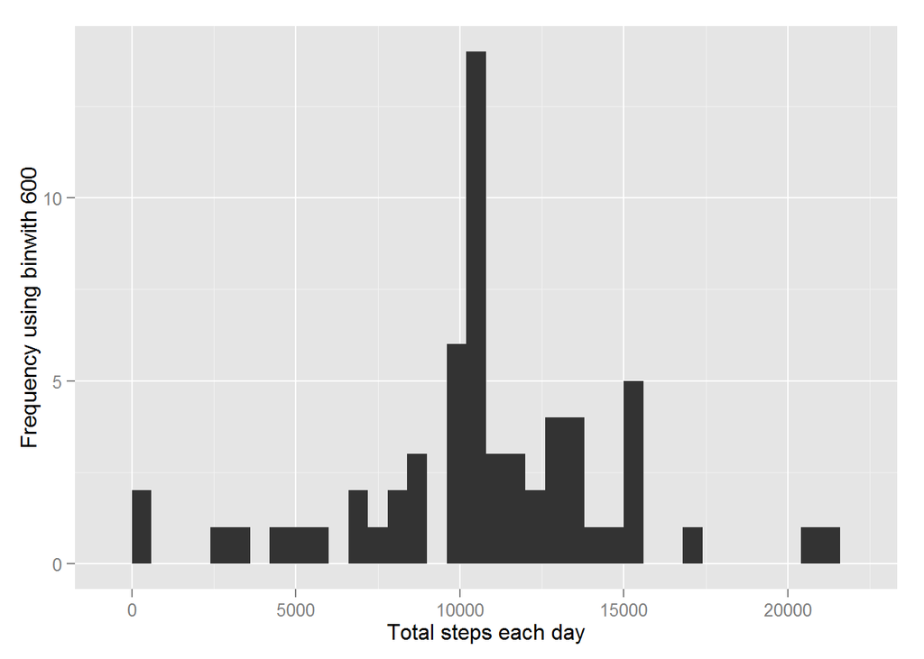

```r
stepsPerDayImputed <- tapply(activityImputed$steps, activityImputed$date, sum)
qplot(stepsPerDayImputed, xlab='Total steps each day', ylab='Frequency using binwith 600', binwidth=600)
```

```r
stepsPerDayMeanImputed <- mean(stepsPerDayImputed)
stepsPerDayMedianImputed <- median(stepsPerDayImputed)
```

### Are there differences in activity patterns between weekdays and weekends?

##### Create a new factor variable in the dataset with two levels – “weekday” and “weekend” indicating whether a given date is a weekday or weekend day.

```r
activityImputed$dateType <-  ifelse(as.POSIXlt(activityImputed$date)$wday %in% c(0,6), 'weekend', 'weekday')
```

##### Make a panel plot containing a time series plot

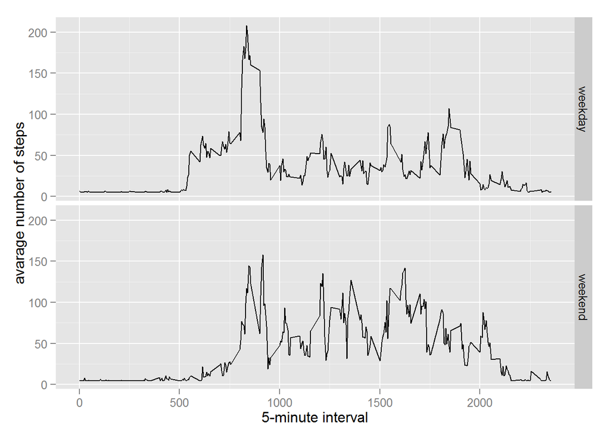

```r
averagedActivityImputed <- aggregate(steps ~ interval + dateType, data=activityImputed, mean)
ggplot(averagedActivityImputed, aes(interval, steps)) +
    geom_line() +
    facet_grid(dateType ~ .) +
    xlab("5-minute interval") +
    ylab("avarage number of steps")
```